# Introduction

## Introduction

In this vignette, we use a real dataset to show how we can apply differential proportionality analysis to RNA-seq count data. We place a particular emphasis here on documenting the differential proportionality measures available through this package. This vignette discusses the `propd` method.

## Theory

Let us consider two non-zero positive vectors, \(X\) and \(Y\), measuring the relative abundance of raw sequence counts. One way to understand whether two vectors associate with one another is to consider the variance of the log-ratios (VLR), a compositionally valid measure of association that makes up part of the definition of the proportionality metrics. Although we can calculate VLR using log-ratio transformed data, the geometric mean or unchanged reference cancels. As such, we can use these counts without any transformation:

\[\textrm{VLR(X, Y)} = \textrm{var}(\log(\textrm{X} / \textrm{Y}))\]

The `propd` method uses the VLR to test for differential proportionality. Recall that the reason we do not use the VLR for proportionality analysis is that we cannot compare the VLR for one pair against the VLR for another pair (thus we defined \(\phi\) and \(\rho\) as a modification to the VLR that gives it scale). However, in differential proportionality analysis, we compare the VLR for one pair across groups. Specifically, we extract the fraction of variance (interpreted as the residual variance of proportional features) where proportionality holds in both or only one of two groups.

We consider here two forms of differential proportionality. The first, which we call *disjointed proportionality*, considers the case where the proportionality of a pair holds in both groups, but the ratio between the partners changes between the groups (i.e., the *slope* of the proportionality changes). The second, which we call *emergent proportionality*, considers the case where there is proportionality in only one of the groups (i.e., the *strength* of the proportionality changes).

Given two groups, sized \(k\) and \(n - k\), we define \(\theta_d\), a measure of *disjointed proportionality*, as the pooled (weighted) VLR within the two groups divided by the total VLR:

\[\theta_d(\textrm{X}, \textrm{Y}) = \frac{(k-1)\textrm{VLR}_1 + (n-k-1)\textrm{VLR}_2}{(n-1)\textrm{VLR}}\]

Likewise, we define \(\theta_e\), a measure of *emergent proportionality*, as the fraction of variance that remains when subtracting the fraction of the dominating group variance:

\[\theta_e(\textrm{X}, \textrm{Y}) = 1 - \frac{\mathrm{max}[(k-1)\textrm{VLR}_1,(n-k-1)\textrm{VLR}_2]}{(n-1)\textrm{VLR}}\]

## Implementation

The `propd` function estimates differential proportionality by calculating \(\theta\) for all feature pairs. This function takes the following arguments as input:

- **counts:** a matrix of \(n\) samples (as rows) and \(d\) features (as columns)
- **group:** an \(n\)-dimensional vector corresponding to subject labels
- **alpha:** an optional argument to trigger and guide transformation
- **p:** the total number of permutations used to estimate FDR

Below, we run `propd` using the `iris` dataset.

```r
library(propr)
data(iris)
keep <- iris$Species %in% c("setosa", "versicolor")
counts <- iris[keep, 1:4] * 10
group <- ifelse(iris[keep, "Species"] == "setosa", "A", "B")
pd <- propd(counts, group, alpha = NA, p = 100)
```

The resultant `propd` object contains both \(\theta_d\) and \(\theta_e\) metrics (among others), although only \(\theta_d\) is *active* by default. While a \(\theta\) is active, it forms the basis for permutation testing (i.e., FDR estimation) and visualization. Users can easily change which \(\theta\) is active using the functions `setDisjointed` and `setEmergent`.

```r
theta_d <- setDisjointed(pd)
theta_e <- setEmergent(pd)
```

Once the \(\theta\) of interest is active, the user can estimate FDR using the `updateCutoffs` function.

```r
theta_d <- updateCutoffs(theta_d, cutoff = seq(0.05, 0.95, 0.3))
```

```
## |------------(25%)----------(50%)----------(75%)----------|
```

```r
theta_e <- updateCutoffs(theta_e, cutoff = seq(0.05, 0.95, 0.3))
```

```
## |------------(25%)----------(50%)----------(75%)----------|
```

In order to reduce RAM overhead, the `propd` object never stores the intermediate \(\theta\) values for permutation testing. However, when a `propd` object is created, it contains all the randomized group assignments needed for permutation testing, meaning that each `updateCutoffs` run effectively uses the same random seed. One could exploit the data contained in the `@permutes` slot to reproduce the intermediate calculations if needed.

## Sample data

To understand differential proportionality, we use two `propd` objects, called `pd.d` (for \(\theta_d\)) and `pd.e` (for \(\theta_e\)), built from the bundled `caneToad.counts` RNA-seq data (Rollins 2015). Specifically, we use the results of the `propd` function as applied to cane toad transcripts with at least 40 counts in all 20 samples (thus removing any transcripts with 0 counts), subsetted to include only pairs with the top 1000 smallest \(\theta\).

Note that in this vignette, we never apply `updateCutoffs` to either data object. When estimating FDR, it is necessary to use an unfiltered `propd` object to keep estimations unbiased.

```r
data(pd.d, package = "propr") # top 1000 disjointed pairs
data(pd.e, package = "propr") # top 1000 emergent pairs
```

## Disjointed proportionality

We begin now by looking at *disjointed proportionality* in more detail. Based on its definition, we see that low values of \(\theta_d\) select pairs where the total VLR far exceeds the weighted sum of the within-group VLRs. Often, the within-group VLRs are about the same size. However, this is not a requirement so long as the within-group VLRs are both small compared to the total VLR.

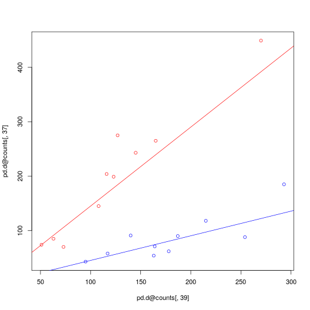

```r
tab <- getResults(pd.d)
plot(pd.d@counts[, 39], pd.d@counts[, 37], col = ifelse(pd.d@group == "WA", "red", "blue"))
grp1 <- pd.d@group == "WA"
grp2 <- pd.d@group != "WA"
abline(a = 0, b = pd.d@counts[grp1, 37] / pd.d@counts[grp1, 39], col = "red")
abline(a = 0, b = pd.d@counts[grp2, 37] / pd.d@counts[grp2, 39], col = "blue")
```

Here, we see that these two features change proportionally across the samples within each group (as expected based on their small values of \(\textrm{VLR}_1\) and \(\textrm{VLR}_2\)). However, when ignoring the group labels, the relationship between these two features appears noisy. Although “37” (y-axis) has increased in expression relative to “39” (x-axis), “37” is no less coordinated with “39”. This change in ratio abundance is apparent when viewed through a per-sample projection.

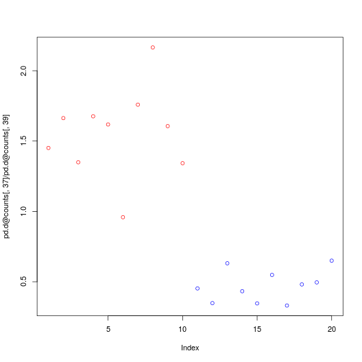

```r
plot(pd.d@counts[, 37] / pd.d@counts[, 39],
     col = ifelse(pd.d@group == "WA", "red", "blue"))
```

This figure shows a clear difference in the ratio abundances between the groups. It also highlights the analogy between disjointed proportionality and differential expression, although the interpretation of differentially abundant ratios differs considerably. Possible biological explanations for this event might include a reduction in the amount of mRNA degradation, a change in isoform splice bias, or an increase in the activity of a transcription factor.

## Emergent proportionality

In contrast, *emergent proportionality* has more in common with a test for differences in correlation coefficients. That is, emergent proportionality occurs when a pair is proportional in one group but not the other, such that the group with no proportionality contributes most of the total variance.

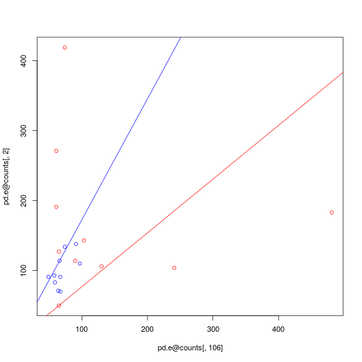

```r
tab <- getResults(pd.e)
plot(pd.e@counts[, 106], pd.e@counts[, 2], col = ifelse(pd.d@group == "WA", "red", "blue"))
grp1 <- pd.e@group == "WA"
grp2 <- pd.e@group != "WA"
abline(a = 0, b = pd.e@counts[grp1, 2] / pd.e@counts[grp1, 106], col = "red")
abline(a = 0, b = pd.e@counts[grp2, 2] / pd.e@counts[grp2, 106], col = "blue")
```

Here, we see that these two features change proportionally across the samples within one group but not the other. In other words, the experimental condition appears to have removed the coordination between the transcripts. Moreover, when ignoring the group labels, we see that one group happens to dominate the total VLR. Interestingly, this has happened here without much change in the average abundance ratio, as apparent when viewed through a per-sample projection.

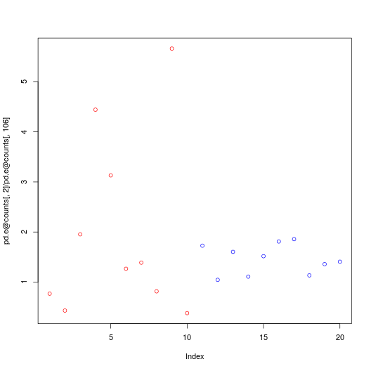

```r
plot(pd.e@counts[, 2] / pd.e@counts[, 106],
     col = ifelse(pd.d@group == "WA", "red", "blue"))
```

This figure confirms that the feature pair varies far more in one group than the other, all while the mean ratio abundances do not change considerably. Note that an increase in \(\theta_e\) tends to impart a decrease in \(\theta_d\). Precisely, \(\theta_e\) relates to \(\theta_d\) via the function:

\[\vartheta_\mathrm{e}=1-\vartheta + \frac{\mathrm{min}[(k-1)\textrm{VLR}_1,(n-k-1)\textrm{VLR}_2]}{(n-1)\textrm{VLR}}\]

From this, we establish the inequality:

\[1-\vartheta\le\vartheta_\mathrm{e}\le1-\vartheta/2,\]

As such, one can use \(1 - \theta_e\) for a stricter definition of *disjointed proportionality*. This is implemented in `propd` as \(\theta_f\), which one can set active using the `setActive` function.

```r
pd.f <- setActive(pd, what = "theta_f")
```

```
## Alert: Update FDR or F-stat manually.
```

## Visualizing log-ratio abundance

The `parallel` function shows the sample-wise distribution of log-ratio abundances for each pair relative to a reference feature. The `include` argument can specify any feature by name. Note that it is not possible to tell from this figure which features have changed in absolute abundance: it is possible for a reference to change relative to its neighbors, for all neighbors to change relative to its reference, or for a reference and its neighbors to have changed simultaneously.

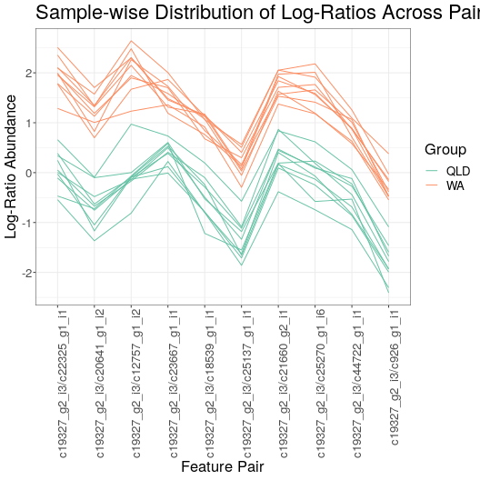

```r
parallel(pd.d, cutoff = .15, include = "c19327_g2_i3")
```

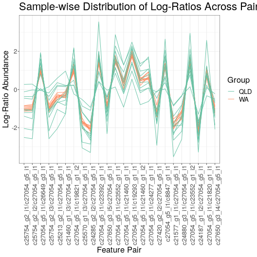

```r
parallel(pd.e, include = "c27054_g5_i1")
```

## References

1. Erb, Ionas, Thomas Quinn, David Lovell, and Cedric Notredame. “Differential Proportionality - A Normalization-Free Approach To Differential Gene Expression.” bioRxiv, May 5, 2017, 134536. http://dx.doi.org/10.1101/134536.
2. Rollins, Lee A., Mark F. Richardson, and Richard Shine. “A Genetic Perspective on Rapid Evolution in Cane Toads (Rhinella Marina).” Molecular Ecology 24, no. 9 (May 2015): 2264-76. http://dx.doi.org/10.1111/mec.13184.